# 3. Pandas 기초 연습문제

1. 딕셔너리를 이용해 아래와 같은 인덱스와 값을 가진 시리즈를 생성하고 출력하시오.

```
학번      202502
이름          지민
중간고사        92
dtype: object
```

```python
# 시리즈는 pandas 패키지 내의 object로 pandas패키지를 임포트 해야함.
import pandas as pd
# 시리즈 인덱스를 가진 1차원 배열
# 딕셔너리를 통해 시리즈를 생성
dic = {
    '학번':202502,
    '이름':'지민',
    '중간고사':92
}
se= pd.Series(dic)
print(se)
```

```
학번      202502
이름          지민
중간고사        92
dtype: object
```

2. 딕셔너리를 사용하지 않고 index 매개변수를 이용해 1번과 동일한 시리즈를 생성하고 출력하시오.

```python
# 딕셔너리를 사용하지 않고 시리즈를 생성하는 법은 index를 직접 지정해주는 것이다.
index = ['학번','이름','중간고사']
value = [202502,'지민',92]
se2= pd.Series(value, index = index)
print(se2)
```

```
학번      202502
이름          지민
중간고사        92
dtype: object
```

3. 딕셔너리를 이용하여 아래와 같은 모양이 되도록 data frame(df)을 생성하시오.

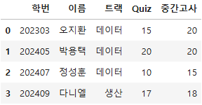

```python
# df를 생성하는 방법은 dataFrame 메서드를 사용하는 것
dic = {
    '학번':[202303,202405,202407,202409],
    '이름':['오지환','박용택','정성훈','다니엘'],
    '트랙':['데이터','데이터','데이터','생산'],
    'Quiz':[15,20,10,17],
    '중간고사':[20,20,15,18]
}
df= pd.DataFrame(dic)
df
```

|  | 학번 | 이름 | 트랙 | Quiz | 중간고사 |
| --- | --- | --- | --- | --- | --- |
| 0 | 202303 | 오지환 | 데이터 | 15 | 20 |
| 1 | 202405 | 박용택 | 데이터 | 20 | 20 |
| 2 | 202407 | 정성훈 | 데이터 | 10 | 15 |
| 3 | 202409 | 다니엘 | 생산 | 17 | 18 |

4. 위 데이터프레임에 행을 추가하여 아래와 같은 모양이 되도록 하시오.  
   단 인덱스는 현재 인덱스 최대값의 다음 값이 되도록 한다.

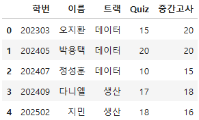

```python
# 현재 인덱스의 최댓값을 구하는 방법?
maxIndex= df.index.max()
df.loc[maxIndex+1] = [202502,'지민','생산',18,16]
df
```

|  | 학번 | 이름 | 트랙 | Quiz | 중간고사 |
| --- | --- | --- | --- | --- | --- |
| 0 | 202303 | 오지환 | 데이터 | 15 | 20 |
| 1 | 202405 | 박용택 | 데이터 | 20 | 20 |
| 2 | 202407 | 정성훈 | 데이터 | 10 | 15 |
| 3 | 202409 | 다니엘 | 생산 | 17 | 18 |
| 4 | 202502 | 지민 | 생산 | 18 | 16 |

5. 위 데이터프레임에서 '정성훈' 학생에 해당하는 행을 삭제한 결과를 새로운 데이터프레임(df2)에 저장하고 출력하시오.

```python
# 이름이 '정성훈'에 해당하는 행을 삭제해야함.
# df에서 행을 삭제하는 방법은 크게 2가지가 있음 1.drop 2.조건절로 삭제
# 1.인덱스를 찾고 drop
# dropindex = df[df['이름']=='정성훈'].index
# df2 = df.drop(dropindex)
# print(df2)
# 2.조건절로 변경
df2 = df[df['이름']!='정성훈']
df2
```

|  | 학번 | 이름 | 트랙 | Quiz | 중간고사 |
| --- | --- | --- | --- | --- | --- |
| 0 | 202303 | 오지환 | 데이터 | 15 | 20 |
| 1 | 202405 | 박용택 | 데이터 | 20 | 20 |
| 3 | 202409 | 다니엘 | 생산 | 17 | 18 |
| 4 | 202502 | 지민 | 생산 | 18 | 16 |

6. 위 데이터프레임(df2)으로부터 인덱싱을 이용하여 이름과 중간고사를 추출하시오.

```python
df2[['이름','중간고사']]
```

|  | 이름 | 중간고사 |
| --- | --- | --- |
| 0 | 오지환 | 20 |
| 1 | 박용택 | 20 |
| 3 | 다니엘 | 18 |
| 4 | 지민 | 16 |

7. 행을 삭제하기 전 원래 데이터프레임(df)에 대해 reindex를 이용하여 2, 0, 4, 1, 3 순으로 순서를 변경하고  
   그 결과를 다시 원래 데이터프레임(df)에 저장하시오. df는 아래와 같아야 함.

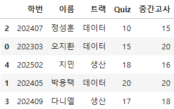

```python
df = df.reindex(index = [2,0,4,1,3])
df
```

|  | 학번 | 이름 | 트랙 | Quiz | 중간고사 |
| --- | --- | --- | --- | --- | --- |
| 2 | 202407 | 정성훈 | 데이터 | 10 | 15 |
| 0 | 202303 | 오지환 | 데이터 | 15 | 20 |
| 4 | 202502 | 지민 | 생산 | 18 | 16 |
| 1 | 202405 | 박용택 | 데이터 | 20 | 20 |
| 3 | 202409 | 다니엘 | 생산 | 17 | 18 |

8. 인덱스가 변경된 데이터프레임(df)에 대해 iloc과 loc을 각각 이용하여 박용택 학생의 record를 추출하시오.  
   (iloc으로 한번, loc으로 한번 수행)  
   이후 모든 문제는 인덱스가 변경된 데이터프레임을 기준으로 함

```python
# iloc은 정수형 인덱스를 통해 접근함 , 즉 현재 박용택 레코드가 위 테이블에서 몇 번째 있는지에 따라 접근 현재 4번째에 존재하니 3을 넣어야함.
df.iloc[3]
# loc은 인덱스 레이블을 통해 접근 , 인덱스 값에 따라 접근 박용택 레코드의 인덱스 값은 1
df.loc[1]
```

```
학번      202405
이름         박용택
트랙         데이터
Quiz        20
중간고사        20
Name: 1, dtype: object
```

9. iloc과 loc을 각각 이용하여 모든 학생의 이름과 중간고사 점수를 추출하시오. (iloc으로 한번, loc으로 한번 수행)

```python
# iloc을 통해서
df.iloc[:,[1,4]]
# loc을 통해서
df.loc[:,['이름','중간고사']]
```

|  | 이름 | 중간고사 |
| --- | --- | --- |
| 2 | 정성훈 | 15 |
| 0 | 오지환 | 20 |
| 4 | 지민 | 16 |
| 1 | 박용택 | 20 |
| 3 | 다니엘 | 18 |

10. 중간고사 점수의 평균을 구하시오.

```python
# mean메서드를 통해 평균을 구할 수 있음
df['중간고사'].mean()
```

```
17.8
```

11. 중간고사 점수가 가장 낮은 학생의 인덱스 라벨을 구하시오.

```python
# 인덱스 라벨을 구하기 위해선 idxmax or idxmin을 사용해야함
df['중간고사'].idxmin()
```

```
2
```

12. 퀴즈 점수가 가장 높은 학생의 학번을 구하시오.

```python
# 퀴즈 점수가 가장 높은 학생의 인덱스를 구하기
idx = df['Quiz'].idxmax()
# 해당 인덱스의 레코드 추출
record = df.loc[idx]
# 시리즈 값에 접근
record['학번']
```

```
202405
```

13. 위 데이터프레임의 각 열에 대해서 개수, 평균, 표준편차, 최소최대값 등의 다양한 통계량을 출력하시오.

```python
# 다양한 통계량을 출력하기 위해서 describe 메서드 사용
df.describe()
```

|  | 학번 | Quiz | 중간고사 |
| --- | --- | --- | --- |
| count | 5.000000 | 5.000000 | 5.000000 |
| mean | 202405.200000 | 16.000000 | 17.800000 |
| std | 70.414487 | 3.807887 | 2.280351 |
| min | 202303.000000 | 10.000000 | 15.000000 |
| 25% | 202405.000000 | 15.000000 | 16.000000 |
| 50% | 202407.000000 | 17.000000 | 18.000000 |
| 75% | 202409.000000 | 18.000000 | 20.000000 |
| max | 202502.000000 | 20.000000 | 20.000000 |

14. 위 데이터프레임을 중간고사 점수에 따라 내림차순으로 정렬하시오.

```python
# 정렬하는 방법은 sort_values 메서드를 사용하고 , 내림차순으로 정렬하기 위해선 ascending 을 False로 설정한다.
df.sort_values('중간고사',ascending=False)
```

|  | 학번 | 이름 | 트랙 | Quiz | 중간고사 |
| --- | --- | --- | --- | --- | --- |
| 0 | 202303 | 오지환 | 데이터 | 15 | 20 |
| 1 | 202405 | 박용택 | 데이터 | 20 | 20 |
| 3 | 202409 | 다니엘 | 생산 | 17 | 18 |
| 4 | 202502 | 지민 | 생산 | 18 | 16 |
| 2 | 202407 | 정성훈 | 데이터 | 10 | 15 |

15. 학생 중에서 퀴즈 점수가 평균 이상인 학생들의 이름을 출력하시오.

```python
# 퀴즈 평균 점수 구하기
quizAverage= df['Quiz'].mean()
# 불리안 인덱싱을 통해 출력
df[df['Quiz']>=quizAverage]['이름']
```

```
4     지민
1    박용택
3    다니엘
Name: 이름, dtype: object
```

16. 학생 중에서 퀴즈와 중간고사 점수 모두 평균 이상인 학생들의 record를 출력하시오.

```python
# 중간고사 평균 점수 구하기
midtermAverage= df['중간고사'].mean()
# 다중 조건문을 설정하기
df[(df['Quiz']>=quizAverage)&(df['중간고사']>= midtermAverage)]
```

|  | 학번 | 이름 | 트랙 | Quiz | 중간고사 |
| --- | --- | --- | --- | --- | --- |
| 1 | 202405 | 박용택 | 데이터 | 20 | 20 |
| 3 | 202409 | 다니엘 | 생산 | 17 | 18 |

17. value_counts를 이용하여 트랙 별로 학생의 수를 구하시오.

```python
df['트랙'].value_counts()
```

```
트랙
데이터    3
생산     2
Name: count, dtype: int64
```